# Kinship Approaches in Demography

Diego Alburez-Gutierrez, Lab of Digital and Computational Demography, Max Planck Institute for Demographic Research

Formal Demography Working Group - Feb 2022

# 1 Why kinship matters

- Socialisation, protection, and sustenance
- Inter-generational solidarity: exchanges and bequests
- Social structure and identity
- Early-life conditions $\rightarrow$ later-life outcomes

# 2 The Elementary Structures of Kinship

Principle of demographic ergodicity:

> A closed population with unchanging mortality and fertility rates has an implied (a) Intrinsic rate of natural increase $r$ and (2) age structure.

Goodman et al (1974): **Stable (and non-stable) populations also have an intrinsic kinship structure**:

> A ﬁxed set of age-speciﬁc rates implies the probability that a girl aged *a* has a living mother and great-grandmother, as well as her expected number of daughters, sisters, aunts, nieces, and cousins. (Keyfitz and Caswell 2005)

For example, this is the expected number of kin for an woman aged 50 (‘Ego’) in a female population that experiences the 2015 Swedish demographic rates ad-infinitum:

[interactive chart not shown]

## 2.1 Assumptions and parameters

1. Stable vs non-stable populations
2. One-sex vs two-sex populations
3. Recursive vs matrix implementations

## 2.2 Ascendants

The probability that a girl aged $a$ has a living mother in a stable population is:

$$\begin{equation}
M_1(a) = \int_{\alpha}^{\beta}{\frac{l(x+a)}{l(x)} e^{-rx}l(x)m(x) dx}.
\tag{2.1}
\end{equation}$$

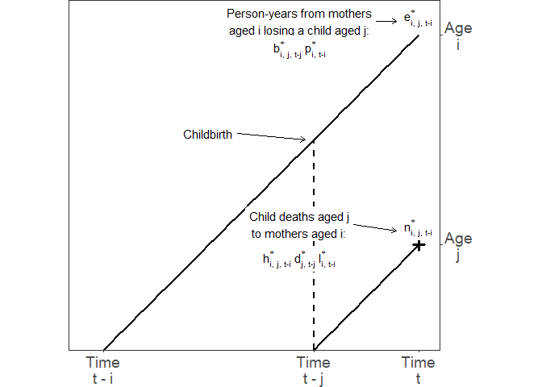

We can define $W(x)$ as the age distribution of the women of girls (Goodman 1974).

$$\begin{equation}
W(x) = e^{-rx}l(x)m(x)
\tag{2.2}
\end{equation}$$

$$\begin{equation}
M_1(a) = \int_{\alpha}^{\beta}{\frac{l(x+a)}{l(x)} W(x) dx}.
\tag{2.1}
\end{equation}$$

This allows us to generalise to older generations. The average number of grandmothers is:

$$\begin{equation}
M_2(a) = \int_{\alpha}^{\beta}{ M_1(x+a) W(x) \:dx}.
\label{eq:m2a}
\end{equation}$$

For great-grandmothers:

$$\begin{equation}
M_3(a) = \int_{\alpha}^{\beta}{ M_2(x+a) W(x) \:dx}.
\label{eq:m3a}
\end{equation}$$

and so on.

## 2.3 Descendants

### 2.3.1 Children

$$\begin{equation}
B_1(a) = \int_{\alpha}^{a}{m(x) l(a-x) \: dx}
\tag{2.3}
\end{equation}$$

## 2.4 Removing the stable assumption

Demographic rates change constantly in the real world - populations are rarely stable.

## 2.6 A Matrix Formulation

A recursive approach can get messy quickly For example, the expected number of younger sisters surviving to ego’s age $a$ is:

$$\begin{equation}
S^{young}(a) = \int_{\alpha}^{\beta}{ \int_{0}^{a}{ \left[ \frac{l(x+u)}{l(x)} \right] m(x+u) l(a-u)\: du } \: e^{-rx}l(x)m(x) \: dx}
\label{eq:sis_young}
\end{equation}$$

where $l(x+u)/l(x)$ is the probability that the mother survives $u$ years after ego’s birth.

New developments by (Caswell 2019, 2020, 2021; Caswell and Song 2021).

# 3 DemoKin: An R package to estimate kinship networks in stable and non-stable populations

**Iván Williams, Diego Alburez-Gutierrez, and Xi Song**; https://github.com/IvanWilli/DemoKin

# 4 Rsoc: Demographic microsimulations in R made easy

**Tom Theile and Diego Alburez-Gutierrez**; https://github.com/tomthe/rsoc

```r
library(rsoc)
folder <- getwd()
seed <- 33

# name of the supplement-file, relative to the above folder:
supfile <- "CousinDiversity.sup"

# run1simulationwithfile starts a simulation with the specified sup-file
rsoc::run1simulationwithfile(folder,supfile,seed)
```

# 5 Applications

## 5.1 Women’s experience of child death

We (Alburez-Gutierrez, Kolk, and Zagheni 2021) showed that the number of children ever born to a woman aged $a$ born in cohort $c$ standing before us will be equal to the number of children who are currently alive plus the children who died before the woman reached age $a$:

$$\begin{equation}
\underbrace{CD(a,c,n)}_{\text{Child deaths}}= \underbrace{\sum_{x=15}^{x=a} {_1F_{x}(c,n)}}_{\text{Children born}}-\underbrace{\sum_{x=15}^{x=a} {_1F_{x}(c,n)} l_{a-x}(c+x,n)}_{\text{Children surviving or } CS(a,c,n) }
\tag{5.1}
\end{equation}$$

where

- $_1F_{x}(c,n)$ are single-year age-specific fertility rates for cohort $c$ and country $n$, at age $x$. The lower age boundary in this and all models is 15, representing the start of a woman’s reproductive life.
- $l_{a-x}(c+x,n)$ is the survival probability until age $(a-x)$ for the cohort born in year $(c+x)$ in country $n$. It is the probability that the children of a woman who gave birth at age $x$ will survive until the woman potentially reaches age $a$.

## 5.2 Sandwich Generation

Given constant age-specific schedules of fertility and mortality rates (Alburez‐Gutierrez, Mason, and Zagheni 2021), we can express the probability of maternal sandwichness at age $a$, $S(a)$, as:

$$\begin{equation}
S(a) = \underbrace{\left(1 - \prod_{x=1}^{\kappa} [1 - m_{a-x})] \right)}_{\substack{\text{fertility risk in the}\\ \text{$\kappa$ years preceding age \emph{a}}}} \times \underbrace{M_1(a)}_{\substack{\text{Prob. that mother of ego}\\ \text{is alive when ego is \emph{a} years old}}} \times \underbrace{\left(1- \frac{M_1(a+\tau)}{M_1(a)}\right)}_{\substack{\text{Prob. that mother of ego}\\ \text{would die within $\tau$ years}}}
\label{eq:sand}
\end{equation}$$

where $m_{a-x}$ is the fertility of women at age $a-x$ and $M_1(a)$ is the probability of having a living mother at age $a$ in a stable population. These estimates refer to an average woman in a female population, ignoring the role of offspring mortality. Conditional on ego’s survival, $M_1{(a)}$ can be thought of as a survival probability in a life table: it has to be equal to one when $a$ is equal to zero (the mother is alive when she gives birth), and goes monotonically to zero. Following the GKP equations, we can estimate $M_1(a)$ given a vector of age-specific fertility rates $m_x$, survival probabilities $l_x$, and the implicit rate of population growth $r$ as:

$$\begin{equation}
M_1(a) = \int_{\alpha}^{\beta}{\frac{l_{x+a}}{l_x}e^{-rx}l_{x}m_{x}dx}
\label{eq:m1a}
\end{equation}$$

$$\begin{equation}
M_1(a) \approx \frac{l_{\mu + a}}{l_{\mu}}.
\label{eq:approx}
\end{equation}$$

## 5.3 Other resources and studies

- Mortality shocks on kinship structure: Zagheni
- Mortality multiplier: Verdery et. al
- Kinship transitions: Murphy
- Bereavement: Smith-Greenaway
- Unemployment in family networks: Song and Caswel
- Kinship and historical memory: Alburez-Gutierrez
- Kin availability: Kolk
- Inheritance of demographic behaviour: Kolk
- Bequests: Zagheni
- Generational overlap:
- Kinlesness:

## References

Alburez-Gutierrez, Diego, Martin Kolk, and Emilio Zagheni. 2021. “Women’s Experience of Child Death over the Life Course: A Global Demographic Perspective.” *Demography* 58 (5): 1715–35. https://doi.org/10.1215/00703370-9420770.

Alburez‐Gutierrez, Diego, Carl Mason, and Emilio Zagheni. 2021. “The ‘Sandwich Generation’ Revisited: Global Demographic Drivers of Care Time Demands.” *Population and Development Review* Advanced publication (September). https://doi.org/10.1111/padr.12436.

Caswell, Hal. 2021. “The Formal Demography of Kinship. IV. Two-Sex Kinship Models.” *(In Preparation)*.

———. 2019. “The Formal Demography of Kinship: A Matrix Formulation.” *Demographic Research* 41 (September): 679–712. https://doi.org/10.4054/DemRes.2019.41.24.

———. 2020. “The Formal Demography of Kinship II: Multistate Models, Parity, and Sibship.” *Demographic Research* 42 (June): 1097–1146. https://doi.org/10.4054/DemRes.2020.42.38.

Caswell, Hal, and Xi Song. 2021. “The Formal Demography of Kinship. III. Kinship Dynamics with Time-Varying Demographic Rates.” *Demographic Research* 45: 517–46.

Goodman, Leo A. 1974. “Family Formation and the Frequency of Various Kinship Relationships.” *Theoretical Population Biology*, 27. https://doi.org/10.1016/0040-5809(74)90049-5.

Keyfitz, Nathan, and Hal Caswell. 2005. *Applied Mathematical Demography*. New York: Springer.